# DATA 621 Final Project - Stock Predictions Methods

Dhairav Chhatbar, Mael Illien, Salma Elshahawy** DATA 621, Master of Science in Data Science, City University of New York

# Abstract

There are a few ways of predicting stock prices. From blind guessing to machine learning, many techniques have been tested to try to achieve decent results. Capturing the complexity of the market in a model is a daunting task but it can be broken down in a number of appraoches.

Since predicting the exact percent increase of a stock the next day is difficult, we can instead try instead to predict the direction of the movement. Alternatively, we can look at the trends and seasonality in the data and try to predict with some level of confidence where the price would like in an arbitrary number of days.

The logistic models which try to predict the direction of the next day’s movement yielded poor results. Hardly any of the predictor variable were significant, and the classification accuracies were around 52% which is hardly better than guessing. On the other hand, the auto-regressive models that predict subsequent values of a stock time series were of greater use. This required finding a suitable combination of parameters to fit the data closely.

# Key Words

1. Time series
2. Logistic regression
3. Auto-regressive models
4. Panel regression

# Introduction

Finding reliable ways to predict stock prices is a difficult exercise and the methods used often yield unsatisfactory results. A lot of stock market data is readily available and it is important to find significant predictors variables amongst all the options. If we believe that the price of a stock, or the direction of its movement can be predicted using recent information then we can look at variables associated with recent movements with indicators such as RSI or moving averages as well as intraday variatioins in price via the OHLC prices.

If on other the hand we believe that trends and long term movements are a better way to predict prices then time series analysis can be used. The analysist consist of comparing a series of prices such as the close price of a stock with a lagged or shifted version of itself in orde to discern any temporal correlations. This technique requires certain assumptions to be met that require transformations of the data. Through different modeling approaches and parameter tuning, we can prediction what future prices will be to a certain degree of confidence.

# Literature Review

# Methodology

- EDA showing basic time series and indicators
- Data preparation: create new variables? created an up/down indicator
- Models to try

The dataset is composed of a variety of stocks. Fur the purpose of brevity, the data exploration will be limited to a single stock, Apple (AAPL). The dataset contains typical pricing variables and it is also augmented with engineered features which are believe to have predictive power. The engineered features used are technical indicators such as the RSI (Relative Strength Indicator), the MACD (Moving Average Convergence Divergence), or simple moving averages.

The logistic models require the creation of a binary target variable. It is calculated by comparing the price of the stock with the price on the following day. If the difference is positive, the target is avaluated as 1, and 0 otherwise. The logistic models are built using Generalized Linear Models suited for the exponential family of distributions (in this case binomial) with the help of the `glm` function.

# Experimentation and Results

### Data Description

The variables description are as follows:

| Variable | Description |
| --- | --- |
| date | Trading Date |
| open | Price of the stock at market open |
| high | Highest price reached in the trade day |
| low | Lowest price reached in the trade day |
| close | Price of the stock at market close |
| volume | Number of shares traded |
| unadjustedVolume | Volume for stocks, unadjusted by stock splits |
| change | Change in closing price from prior trade day close |
| changePercent | Percentage change in closing price from prior trade day close |
| vwap | Volume weighted average price (VWAP) is the ratio of the value traded to total volume traded |
| label | Trading Date |
| changeOverTime | Percent change of each interval relative to first value. Useful for comparing multiple stocks. |
| ticker | Abbreviation used to uniquely identify publicly traded shares |

```r
dataset <- read_csv('https://raw.githubusercontent.com/salma71/Data_621/master/Project_Proposal/stocks_combined.csv')
tickers <- read_csv('https://raw.githubusercontent.com/salma71/Data_621/master/Project_Proposal/tickers.csv')
```

The tickers available in this dataset are listed below. We will be focusing on the AAPL stock which is described below.

```r
tickers
```

| Ticker | Company |
| --- | --- |
| AAPL | Apple Inc |
| AXP | American Express Company |
| BA | Boeing Co |
| CAT | Caterpillar Inc. |
| CSCO | Cisco Systems, Inc. |
| CVX | Chevron Corporation |
| DIS | Walt Disney Co |
| DWDP | DowDuPont |
| GS | GlaxoSmithKline plc |
| HD | The Home Depot, Inc. |

[output cut: 20 more lines]

```r
skim(dataset)
```

Data summary

| Name | dataset |
| --- | --- |
| Number of rows | 36850 |
| Number of columns | 13 |
| _______________________ |  |
| Column type frequency: |  |
| character | 3 |
| numeric | 10 |
| ________________________ |  |
| Group variables | None |

**Variable type: character**

| skim_variable | n_missing | complete_rate | min | max | empty | n_unique | whitespace |
| --- | --- | --- | --- | --- | --- | --- | --- |
| date | 0 | 1 | 8 | 10 | 0 | 1258 | 0 |
| ticker | 0 | 1 | 1 | 4 | 0 | 30 | 0 |
| label | 0 | 1 | 5 | 9 | 0 | 1258 | 0 |

**Variable type: numeric**

| skim_variable | n_missing | complete_rate | mean | sd | p0 | p25 | p50 | p75 | p100 | hist |
| --- | --- | --- | --- | --- | --- | --- | --- | --- | --- | --- |
| open | 0 | 1 | 94.52 | 52.68 | 18.17 | 56.83 | 84.09 | 118.30 | 417.14 | ▇▅▁▁▁ |
| high | 0 | 1 | 95.25 | 53.14 | 18.41 | 57.40 | 84.67 | 119.14 | 421.84 | ▇▅▁▁▁ |
| low | 0 | 1 | 93.76 | 52.19 | 18.11 | 56.19 | 83.54 | 117.39 | 417.11 | ▇▅▁▁▁ |
| close | 0 | 1 | 94.53 | 52.68 | 18.18 | 56.77 | 84.09 | 118.32 | 421.55 | ▇▅▁▁▁ |
| volume | 0 | 1 | 11196571.67 | 12461717.47 | 305358.00 | 3977137.50 | 7045060.00 | 13777850.50 | 618237630.00 | ▇▁▁▁▁ |
| unadjustedVolume | 0 | 1 | 10967241.59 | 12152154.22 | 305358.00 | 3817578.50 | 6895243.00 | 13581565.00 | 618237630.00 | ▇▁▁▁▁ |
| change | 0 | 1 | 0.05 | 1.50 | -23.45 | -0.43 | 0.04 | 0.56 | 65.29 | ▁▇▁▁▁ |
| changePercent | 0 | 1 | 0.05 | 1.30 | -14.34 | -0.56 | 0.05 | 0.70 | 16.67 | ▁▁▇▁▁ |
| vwap | 0 | 1 | 94.52 | 52.68 | 13.79 | 56.79 | 84.11 | 118.24 | 420.32 | ▇▅▁▁▁ |
| changeOverTime | 0 | 1 | 0.38 | 0.50 | -0.41 | 0.06 | 0.24 | 0.54 | 3.19 | ▇▅▁▁▁ |

```r
head(dataset)
```

| date | ticker | open | high | low | close | volume | unadjustedVolume | change | changePercent | vwap | label | changeOverTime |
| --- | --- | --- | --- | --- | --- | --- | --- | --- | --- | --- | --- | --- |
| 2/21/2014 | AAPL | 69.9727 | 70.2061 | 68.8967 | 68.9821 | 69757247 | 9965321 | -0.774858 | -1.111 | 69.4256 | 21-Feb-14 | 0.000000000 |
| 2/24/2014 | AAPL | 68.7063 | 69.5954 | 68.6104 | 69.2841 | 72364950 | 10337850 | 0.302061 | 0.438 | 69.1567 | 24-Feb-14 | 0.004377947 |
| 2/25/2014 | AAPL | 69.5245 | 69.5488 | 68.4239 | 68.5631 | 58247350 | 8321050 | -0.721010 | -1.041 | 68.9153 | 25-Feb-14 | -0.006074039 |
| 2/26/2014 | AAPL | 68.7667 | 68.9492 | 67.7147 | 67.9446 | 69131286 | 9875898 | -0.618575 | -0.902 | 68.1373 | 26-Feb-14 | -0.015040134 |
| 2/27/2014 | AAPL | 67.9170 | 69.4457 | 67.7738 | 69.2999 | 75557321 | 10793903 | 1.355300 | 1.995 | 68.8615 | 27-Feb-14 | 0.004606992 |
| 2/28/2014 | AAPL | 69.4851 | 69.9671 | 68.5710 | 69.1121 | 93074653 | 13296379 | -0.187807 | -0.271 | 69.2731 | 28-Feb-14 | 0.001884547 |

### Data Processing

The only necessary processing of the data is formatting the date column appropriately.

```r
dataset$date <- as.Date(dataset$date, format="%m/%d/%Y")
```

#### Feature Engineering

The dataset is augmented with technicals indicators from the `ta-lib` package and the target variable for the logistic model is created. Observations are required to be dropped where NA values are introduced due to the shifting required by the window functions. We are interested in rates of change instead of value in order to be able to any stocks, which will not have the same price.

- *TARGET*: the binaby target variable for the logistic model
- *MACD*: the MACD signal (only) using the typical 12 and 26 window sizes
- *m5*: momentum indicator over the last 5 days (moving average of one trading week)
- *m20*: momentum indicator over the last 20 days (moving average of one trading month)
- *vol1*: rate of change of the volume over the last day
- *vol5*: rate of change of the volume over the last five dasy (one trading week)

```r
AAPL <- dataset %>% filter(ticker=='AAPL')

# Augment data frame
AAPL_full <- AAPL %>% mutate(macd=MACD(Cl(AAPL), nFast=12, nSlow=26, nSig=9, maType=SMA)[,1],
                        m5=momentum(AAPL$close, n=5),
                        m20=momentum(AAPL$close, n=20),
                        rsi=RSI(AAPL$close, n=14),
                        vol1=ROC(AAPL$volume, n=1),
                        vol5=ROC(AAPL$volume, n=5)) %>%
                        drop_na() %>%
                      select(-c(date,ticker,label, changeOverTime))

# Create target variable
AAPL_model1_data <- AAPL_full%>%
                  mutate(TARGET=if_else(shift(close, n=1, fill=NA, type="lead") > close, 1, 0)) %>%
                  #select(-c(date,ticker,label,open,high,low,close,volume,unadjustedVolume,vwap,change,changeOverTime)) %>%
                  drop_na()

AAPL_model1_data$TARGET <- factor(AAPL_model1_data$TARGET)
```

```r
head(AAPL_model1_data,10)
```

| open | high | low | close | volume | unadjustedVolume | change | changePercent | vwap | macd | m5 | m20 | rsi | vol1 | vol5 | TARGET |
| --- | --- | --- | --- | --- | --- | --- | --- | --- | --- | --- | --- | --- | --- | --- | --- |
| 70.6986 | 70.7800 | 70.1641 | 70.5068 | 50141063 | 7163009 | -0.078800 | -0.112 | 70.5193 | 0.5050515 | 0.5240 | 1.3947 | 56.79133 | -0.10168102 | -0.6243201 | 0 |
| 70.8181 | 71.0256 | 70.3847 | 70.4911 | 42167188 | 6023884 | -0.015758 | -0.022 | 70.6164 | 0.5169691 | -0.3217 | 1.1794 | 56.63724 | -0.17319791 | -0.7461495 | 1 |
| 70.6250 | 71.1648 | 70.4950 | 71.1359 | 50189685 | 7169955 | 0.644839 | 0.915 | 70.8293 | 0.6801634 | -0.4387 | 1.3671 | 61.28351 | 0.17416714 | -0.3408432 | 1 |
| 71.2318 | 71.3763 | 70.9534 | 71.2541 | 44792195 | 6398885 | 0.118198 | 0.166 | 71.1644 | 0.7785151 | 0.3638 | 1.3383 | 62.08551 | -0.11377562 | -0.5146836 | 0 |
| 71.1018 | 71.2475 | 70.6093 | 70.7603 | 40648111 | 5806873 | -0.493807 | -0.693 | 70.9206 | 0.7381852 | 0.1747 | 1.0559 | 56.79271 | -0.09708154 | -0.3115690 | 0 |
| 70.8943 | 70.9192 | 69.6821 | 69.8449 | 68812485 | 9830355 | -0.915383 | -1.294 | 70.0967 | 0.7168008 | -0.6619 | 0.1812 | 48.53281 | 0.52643283 | 0.3165449 | 0 |
| 69.3459 | 69.7241 | 68.5408 | 68.7483 | 72462530 | 10351790 | -1.096600 | -1.570 | 68.9934 | 0.6552382 | -1.7428 | -0.9784 | 40.86523 | 0.05168440 | 0.5414272 | 0 |
| 68.9742 | 69.0963 | 68.1219 | 68.7444 | 60971883 | 8710269 | -0.003941 | -0.006 | 68.6783 | 0.5392966 | -2.3915 | -1.6613 | 40.84052 | -0.17265678 | 0.1946033 | 1 |
| 68.6393 | 69.6703 | 68.5579 | 69.6479 | 51542722 | 7363246 | 0.903566 | 1.314 | 69.2064 | 0.4074158 | -1.6062 | -0.8261 | 48.59596 | -0.16800181 | 0.1403771 | 0 |
| 69.6952 | 69.9001 | 68.7089 | 68.7496 | 59912818 | 8558974 | -0.898310 | -1.290 | 69.2110 | 0.1355157 | -2.0107 | -0.9417 | 42.61437 | 0.15047946 | 0.3879381 | 0 |

### Data Exploration

The stock price for AAPL over the years are risen steadily. There are two important periods of decline but the overall trends remains positive. These periods of decline should provide balance to the dataset.

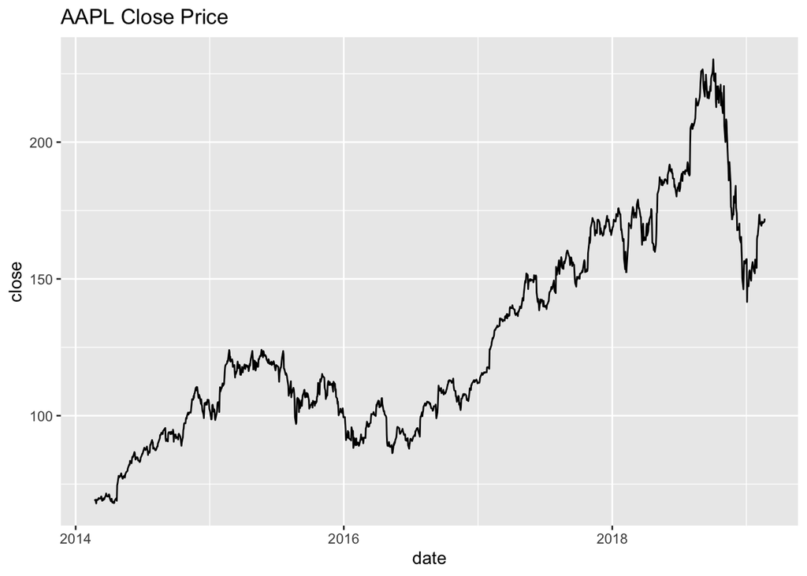

```r
AAPL %>% ggplot(aes(x=date,y=close)) + geom_line() + ggtitle('AAPL Close Price')
```

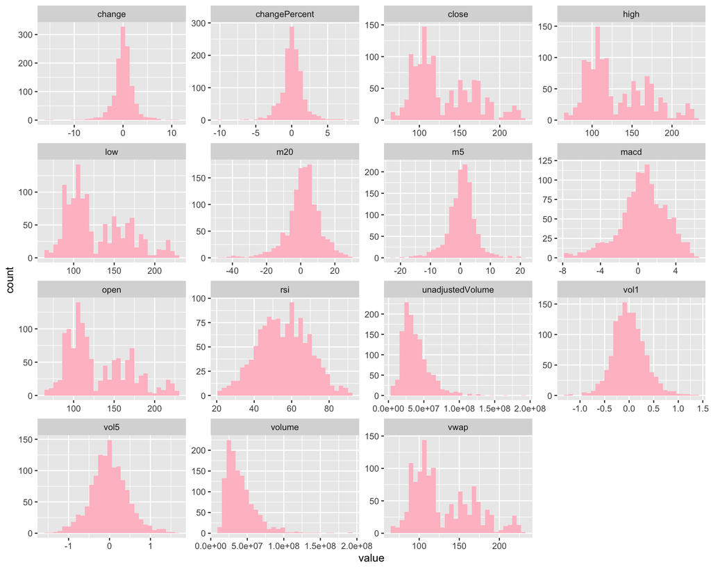

```r
AAPL_full %>%
  keep(is.numeric) %>%
  gather() %>%
  ggplot(aes(x= value)) +
  geom_histogram(fill='pink') +
  facet_wrap(~key, scales = 'free')
```

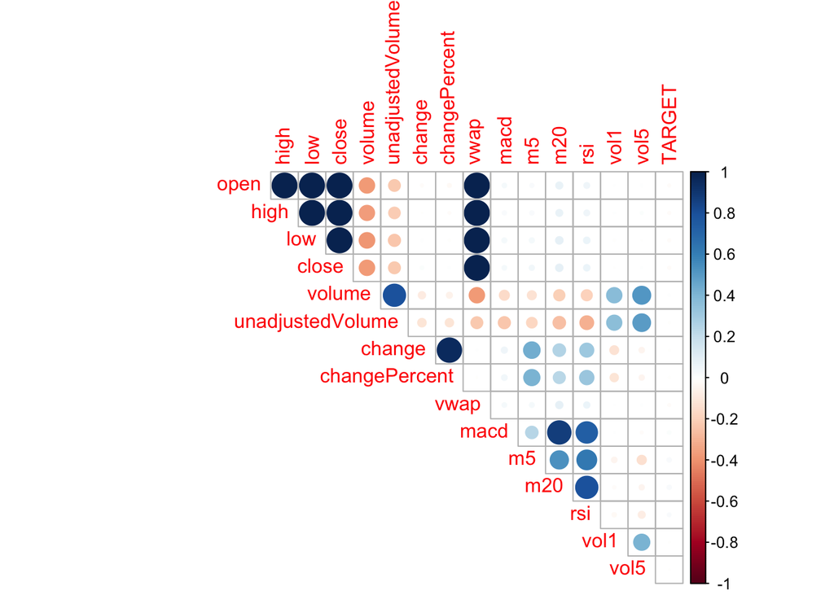

```r
library(corrplot)
corr_dataframe <- AAPL_model1_data %>% mutate_if(is.factor, as.numeric)
corr.d <- cor(corr_dataframe)
corr.d[ lower.tri( corr.d, diag = TRUE ) ] <- NA
corrplot( corr.d, type = "upper", diag = FALSE )
```

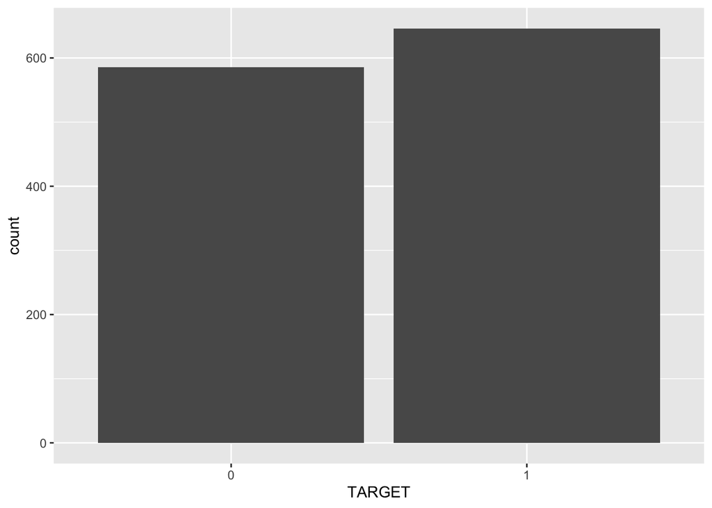

```r
AAPL_model1_data %>% ggplot(aes(x=TARGET)) + geom_histogram(stat="count")
```

### Modeling

#### Model 1 (Logistic)

```r
# Initialize a df that will store the metrics of models
models.df <- tibble(id=character(), formula=character(), res.deviance=numeric(), null.deviance=numeric(),
                 aic=numeric(), accuracy=numeric(), sensitivity=numeric(), specificity=numeric(),
                precision.deviance=numeric(), stringsAsFactors=FALSE)
```

#### M1A Full Model

The first logistic model yields unsatisfactory results. Only the `close` variable is significant. It is revealed that a lot of the variables are multicollinear. This makes sense given that a number of variables are related to the price are generally move together (close, open, low, high), and some are derived from other variables. The model should be reduced by removing the least significant predictors until the model is significant.

```r
model.full <- build_model('model.full', "TARGET ~ .", data = AAPL_model1_data)
```

```
##
## Call:
## glm(formula = formula, family = binomial(link = "logit"), data = data)
##
## Deviance Residuals:
##    Min      1Q  Median      3Q     Max
## -1.526  -1.214   1.016   1.136   1.516
##
## Coefficients:
##                    Estimate Std. Error z value Pr(>|z|)
## (Intercept)       2.671e-01  6.027e-01   0.443   0.6577
## open              8.583e-03  8.433e-02   0.102   0.9189
## high             -1.930e-03  1.517e-01  -0.013   0.9899
## low              -4.638e-02  1.281e-01  -0.362   0.7172
## close            -2.640e-01  1.042e-01  -2.533   0.0113 *
## volume            2.347e-09  5.330e-09   0.440   0.6597
## unadjustedVolume -3.069e-09  5.218e-09  -0.588   0.5563
## change            7.907e-02  1.042e-01   0.759   0.4479
## changePercent    -5.918e-02  1.341e-01  -0.441   0.6590
## vwap              3.025e-01  2.193e-01   1.379   0.1678
## macd             -2.321e-02  6.687e-02  -0.347   0.7286
## m5                1.059e-02  2.147e-02   0.493   0.6218
## m20               1.028e-02  1.728e-02   0.595   0.5520
## rsi              -8.145e-04  9.055e-03  -0.090   0.9283
## vol1             -3.231e-02  1.985e-01  -0.163   0.8707
## vol5             -4.458e-03  1.609e-01  -0.028   0.9779
## ---
## Signif. codes:  0 '***' 0.001 '**' 0.01 '*' 0.05 '.' 0.1 ' ' 1
##
## (Dispersion parameter for binomial family taken to be 1)
##
##     Null deviance: 1705.0  on 1231  degrees of freedom
## Residual deviance: 1694.3  on 1216  degrees of freedom
## AIC: 1726.3
##
## Number of Fisher Scoring iterations: 4
```

```r
models.df <- rbind(models.df,model.full$df_info)
summary(model.full)
```

```
##         Length Class  Mode
## model   30     glm    list
## df_info  9     tbl_df list
```

[output not shown]

#### M1B Small Model

Reducing the model down to only the significant predictors leads to a nonsensical results where the two variables cancel each other out.

```r
model.small <- build_model('model.small', "TARGET ~ .-vol5 -high -rsi -open -vol1-changePercent-low-macd-m20-volume-unadjustedVolume-m5-change", data = AAPL_model1_data)
```

```
##
## Call:
## glm(formula = formula, family = binomial(link = "logit"), data = data)
##
## Deviance Residuals:
##    Min      1Q  Median      3Q     Max
## -1.534  -1.214   1.044   1.136   1.356
##
## Coefficients:
##             Estimate Std. Error z value Pr(>|z|)
## (Intercept)  0.19119    0.20539   0.931   0.3519
## close       -0.16739    0.07510  -2.229   0.0258 *
## vwap         0.16665    0.07511   2.219   0.0265 *
## ---
## Signif. codes:  0 '***' 0.001 '**' 0.01 '*' 0.05 '.' 0.1 ' ' 1
##
## (Dispersion parameter for binomial family taken to be 1)
##
##     Null deviance: 1705.0  on 1231  degrees of freedom
## Residual deviance: 1699.6  on 1229  degrees of freedom
## AIC: 1705.6
##
## Number of Fisher Scoring iterations: 4
```

```r
models.df <- rbind(models.df,model.small$df_info)
summary(model.small)
```

```
##         Length Class  Mode
## model   30     glm    list
## df_info  9     tbl_df list
```

#### M1C Multicollinearity Removed

This model removes a lot of the predictors (open,high,low,vwap,change,macd) but adds `Close2Open` and `Open2Open` in order to try to retain some information from the variables that were dropped. The removed variables were determined to be too correlated and we retained only the predictors with Variance Inflation Factors below an allowable treshold as seen below. Unfortunately, this model also lacks significance.

```r
m1c_data <- AAPL_model1_data
m1c_data$Close2Open <- m1c_data$open - shift(m1c_data$close, n=1, fill=NA, type="lag")
m1c_data$Open2Open <- m1c_data$open - shift(m1c_data$open, n=1, fill=NA, type="lag")
m1c_data_trimmed <- m1c_data %>% select(-c(open,high,low,vwap,change,macd)) %>% drop_na()

model.m1c  <- build_model('model.m1c', "TARGET ~ .", data = m1c_data_trimmed )
```

```
##
## Call:
## glm(formula = formula, family = binomial(link = "logit"), data = data)
##
## Deviance Residuals:
##    Min      1Q  Median      3Q     Max
## -1.452  -1.215   1.041   1.133   1.522
##
## Coefficients:
##                    Estimate Std. Error z value Pr(>|z|)
## (Intercept)       2.315e-01  5.546e-01   0.417    0.676
## close            -6.350e-04  1.716e-03  -0.370    0.711
## volume            3.806e-09  5.157e-09   0.738    0.461
## unadjustedVolume -3.337e-09  5.102e-09  -0.654    0.513
## changePercent    -8.424e-02  5.278e-02  -1.596    0.110
## m5                1.639e-02  1.749e-02   0.937    0.349
## m20               4.954e-03  9.862e-03   0.502    0.615
## rsi              -1.601e-03  7.907e-03  -0.202    0.840
## vol1             -2.477e-02  1.974e-01  -0.126    0.900
## vol5             -1.477e-02  1.599e-01  -0.092    0.926
## Close2Open        1.055e-01  7.038e-02   1.499    0.134
## Open2Open        -1.718e-02  3.825e-02  -0.449    0.653
##
## (Dispersion parameter for binomial family taken to be 1)
##
##     Null deviance: 1703.5  on 1230  degrees of freedom
## Residual deviance: 1697.7  on 1219  degrees of freedom
## AIC: 1721.7
##
## Number of Fisher Scoring iterations: 4
```

```r
models.df <- rbind(models.df,model.m1c$df_info)
summary(model.m1c)
```

```
##         Length Class  Mode
## model   30     glm    list
## df_info  9     tbl_df list
```

```r
car::vif(model.m1c$model)
```

```
##            close           volume unadjustedVolume    changePercent
##         1.271410         3.558891         3.154121         2.017531
##               m5              m20              rsi             vol1
##         2.014173         2.882669         3.543602         1.306379
##             vol5       Close2Open        Open2Open
##         1.619487         2.799758         2.131832
```

#### Logistic Model Results

The results of the logistic models are displayed below. The in-sample testing accuracy is fairly low at 52%. No model has a particular edge so we proceed to move on to other types of model. This exercise could be enhanced by using data from other stocks by removing all the variables that are stock dependent. Additionally, more target could be used such as the the direction of the price movement over 5 days or 20 days.

```r
models.df
```

| id | formula | res.deviance | null.deviance | aic | accuracy | sensitivity | specificity | precision |
| --- | --- | --- | --- | --- | --- | --- | --- | --- |
| model.full | TARGET ~ . | 1694.285 | 1704.991 | 1726.285 | 0.528 | 0.817 | 0.208 | 0.532 |
| model.small | TARGET ~ .-vol5 -high -rsi -open -vol1-changePercent-low-macd-m20-volume-unadjustedVolume-m5-change | 1699.643 | 1704.991 | 1705.643 | 0.526 | 0.854 | 0.164 | 0.530 |
| model.m1c | TARGET ~ . | 1697.708 | 1703.504 | 1721.708 | 0.528 | 0.865 | 0.156 | 0.531 |

### Model 2 - Autoregressive Model

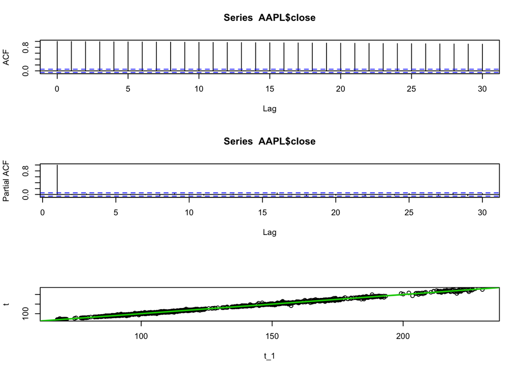

```r
par(mfrow=c(3,1))
acf(AAPL$close)
pacf(AAPL$close)

t <- AAPL$close[-1]
t_1 <- AAPL$close[-length(AAPL$close)]
m2.lm <- lm(t ~ t_1)

plot(t_1, t)
abline(m2.lm, col=3, lwd=2)
```

```r
summary(m2.lm)
```

```
##
## Call:
## lm(formula = t ~ t_1)
##
## Residuals:
##      Min       1Q   Median       3Q      Max
## -15.6872  -0.8211  -0.0341   0.9425  11.1222
##
## Coefficients:
##             Estimate Std. Error t value Pr(>|t|)
## (Intercept) 0.340328   0.210876   1.614    0.107
## t_1         0.997991   0.001572 634.859   <2e-16 ***
## ---
## Signif. codes:  0 '***' 0.001 '**' 0.01 '*' 0.05 '.' 0.1 ' ' 1
##
## Residual standard error: 2.129 on 1255 degrees of freedom
## Multiple R-squared:  0.9969, Adjusted R-squared:  0.9969
## F-statistic: 4.03e+05 on 1 and 1255 DF,  p-value: < 2.2e-16
```

#### Generalized Least Squares

```r
# Assuming 200 trading days in a year
AAPL_ts <- ts(AAPL$close, start=c(2014, 2, 21), end=c(2019, 2, 20), frequency=200)
AAPL_close <- ts(AAPL$close)
```

```r
m2.gls <- gls(AAPL_close ~ time(AAPL_close), correlation = corAR1(form=~1))
summary(m2.gls)$tTable
```

```
##                        Value    Std.Error    t-value   p-value
## (Intercept)      68.90127003 3.174416e+03 0.02170518 0.9826866
## time(AAPL_close)  0.08197924 6.006749e-02 1.36478539 0.1725650
```

```r
ar(AAPL_close)
```

```
##
## Call:
## ar(x = AAPL_close)
##
## Coefficients:
##     1
## 0.997
##
## Order selected 1  sigma^2 estimated as  8.862
```

```r
#m2.gls2 <- gls(AAPL_close ~ time(AAPL_close), correlation = corARMA(p=2))
#summary(m2.gls2)
```

#### ARIMA

Time series needs to be stationary. The higher order differentials have mean 0 but the varaince seems to increase in the last part of the series. Below we series the series differentiated to the first and second order.

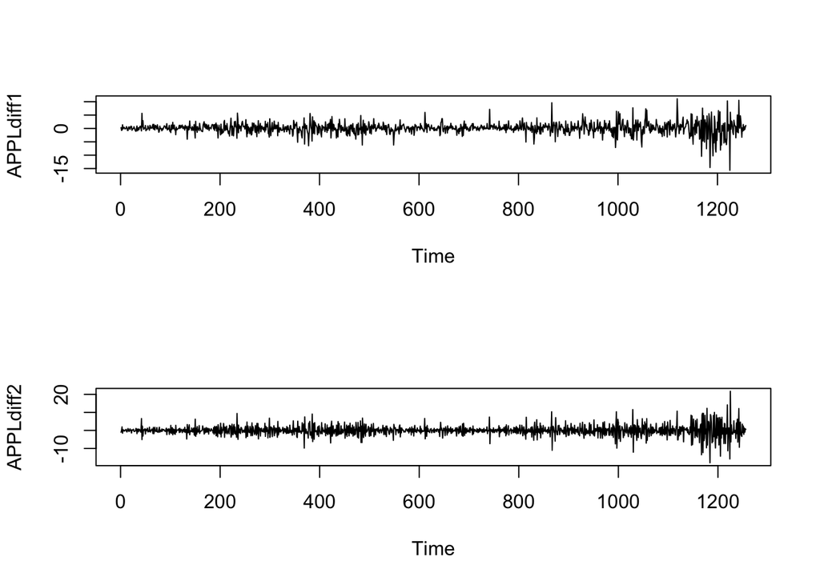

```r
par(mfrow=c(2,1))
APPLdiff1 <- diff(AAPL$close, differences=1)
APPLdiff2 <- diff(AAPL$close, differences=2)
plot.ts(APPLdiff1)
plot.ts(APPLdiff2)
```

##### Order 1 differential

The order 1 differential shows rhe highest correlation at position 0, while the partial ACF seenms to show periodic behavior with a few significant lags which does not tell us much.

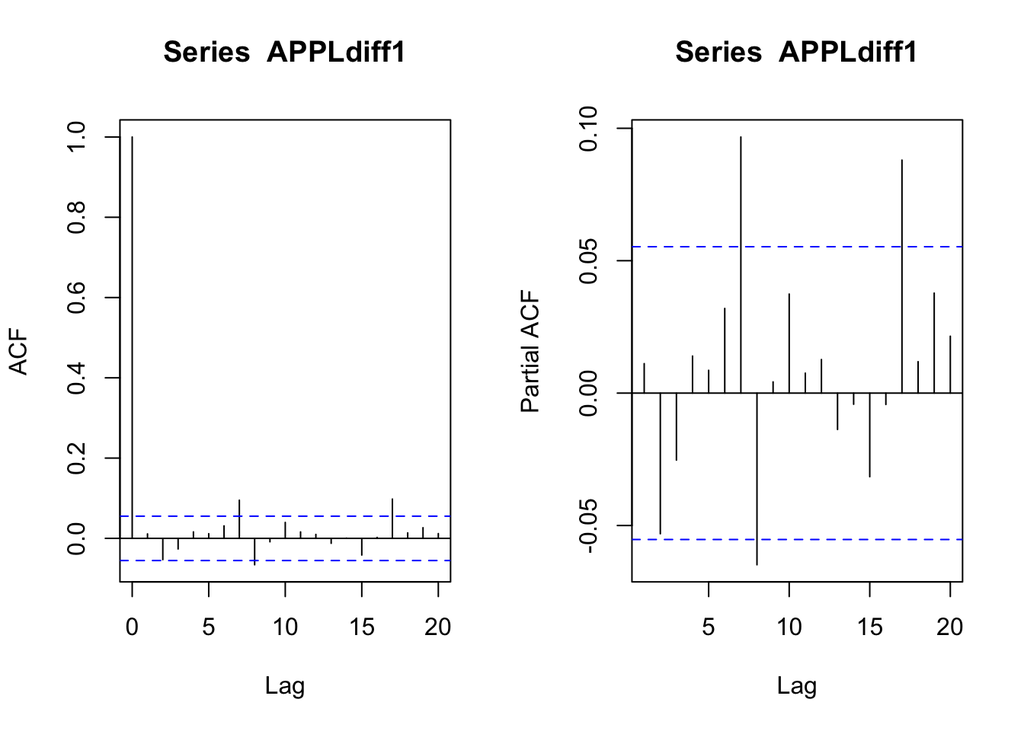

```r
par(mfrow=c(1,2))
acf(APPLdiff1, lag.max=20)
pacf(APPLdiff1, lag.max=20)
```

```r
acf(APPLdiff1, lag.max=20, plot=FALSE)
```

```
##
## Autocorrelations of series 'APPLdiff1', by lag
##
##      0      1      2      3      4      5      6      7      8      9     10
##  1.000  0.011 -0.053 -0.026  0.016  0.012  0.031  0.095 -0.066 -0.009  0.040
##     11     12     13     14     15     16     17     18     19     20
##  0.016  0.010 -0.012  0.001 -0.042  0.002  0.098  0.014  0.027  0.012
```

```r
pacf(APPLdiff1, lag.max=20, plot=FALSE)
```

```
##
## Partial autocorrelations of series 'APPLdiff1', by lag
##
##      1      2      3      4      5      6      7      8      9     10     11
##  0.011 -0.053 -0.025  0.014  0.009  0.032  0.097 -0.065  0.004  0.037  0.008
##     12     13     14     15     16     17     18     19     20
##  0.013 -0.014 -0.004 -0.032 -0.004  0.088  0.012  0.038  0.021
```

##### Order 2 differential

On the other hand, the order two differential has several meaningful lags we can use, and the partial ACF decays.

```r
par(mfrow=c(1,2))
acf(APPLdiff2, lag.max=20)             # plot a correlogram
acf(APPLdiff2, lag.max=20, plot=FALSE) # get the autocorrelation values
```

```
##
## Autocorrelations of series 'APPLdiff2', by lag
##
##      0      1      2      3      4      5      6      7      8      9     10
##  1.000 -0.468 -0.046 -0.008  0.024 -0.012 -0.022  0.114 -0.110  0.004  0.036
##     11     12     13     14     15     16     17     18     19     20
## -0.009  0.008 -0.018  0.027 -0.043 -0.026  0.090 -0.049  0.014 -0.023
```

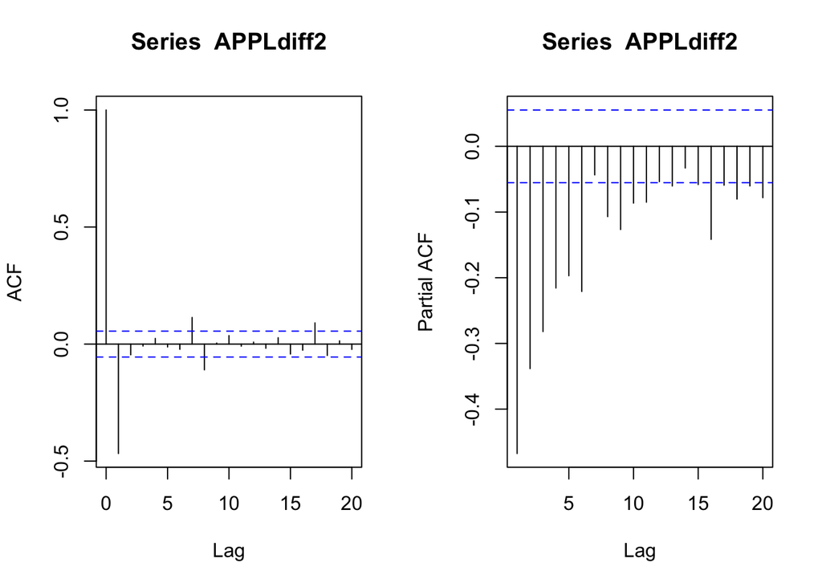

```r
pacf(APPLdiff2, lag.max=20)
```

```r
pacf(APPLdiff2, lag.max=20, plot=FALSE)
```

```
##
## Partial autocorrelations of series 'APPLdiff2', by lag
##
##      1      2      3      4      5      6      7      8      9     10     11
## -0.468 -0.338 -0.282 -0.216 -0.197 -0.221 -0.043 -0.107 -0.127 -0.086 -0.085
##     12     13     14     15     16     17     18     19     20
## -0.054 -0.060 -0.033 -0.058 -0.142 -0.059 -0.080 -0.060 -0.078
```

AR(1), differential(2), MA(0)

```r
arimadf <- tibble(model=character(), coef=character(), loglik=numeric(), aic=numeric())

arimamodels <- function(p,d,q) {
  # A specification of the non-seasonal part of the ARIMA model: the three components (p, d, q) are the AR order, the degree of differencing, and the MA order. ARMA(p,q)
  arima.model <- arima(AAPL$close, order = c(p,d,q))
  arima.model_fitted <- AAPL$close - residuals(arima.model)
  df <- tibble(model=paste0(p,d,q), coef=paste0(list(round(arima.model$coef,3)), loglik=arima.model$loglik, aic=arima.model$aic))
  return.list <- list(model=arima.model,fitted=arima.model_fitted, df=df)
  return(return.list)
}
```

```r
m120 <- arimamodels(p=1, d=2, q=0)
arimadf <- rbind(arimadf, m120$df)
m021 <- arimamodels(0, 2, 1)
arimadf <- rbind(arimadf, m021$df)
m620 <- arimamodels(6, 2, 0)
arimadf <- rbind(arimadf, m620$df)
m621 <- arimamodels(6, 2, 1)
arimadf <- rbind(arimadf, m621$df)

arimadf
```

[output not shown]

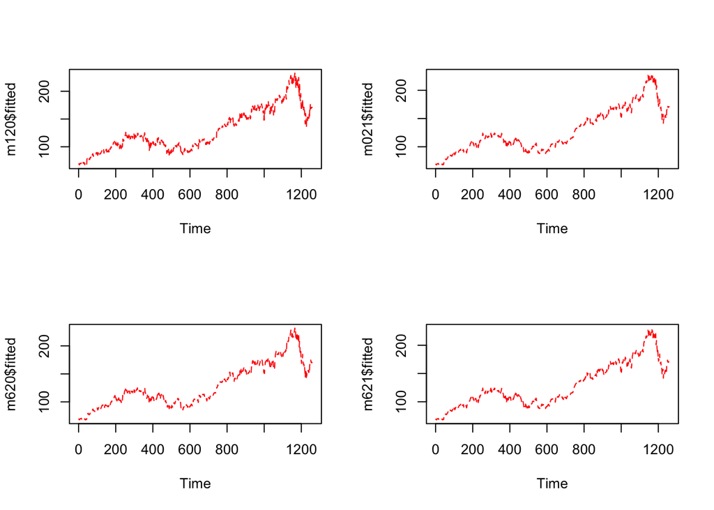

```r
par(mfrow=c(2,2))
#plot(AAPL$close, type = "l", col = 4, lty = 1)
plot(m120$fitted, type = "l", col = 2, lty = 2)
#plot(AAPL$close, type = "l", col = 4, lty = 1)
plot(m021$fitted, type = "l", col = 2, lty = 2)
#plot(AAPL$close, type = "l", col = 4, lty = 1)
plot(m620$fitted, type = "l", col = 2, lty = 2)
#plot(AAPL$close, type = "l", col = 4, lty = 1)
plot(m621$fitted, type = "l", col = 2, lty = 2)
```

```r
# A specification of the non-seasonal part of the ARIMA model: the three components (p, d, q) are the AR order, the degree of differencing, and the MA order.
model2.arima021 <- arima(AAPL$close, order = c(0, 2, 1))
model2.arima021_fitted <- AAPL$close - residuals(model2.arima021)
model2.arima021
```

```
##
## Call:
## arima(x = AAPL$close, order = c(0, 2, 1))
##
## Coefficients:
##          ma1
##       -1.000
## s.e.   0.003
##
## sigma^2 estimated as 4.536:  log likelihood = -2735.32,  aic = 5474.65
```

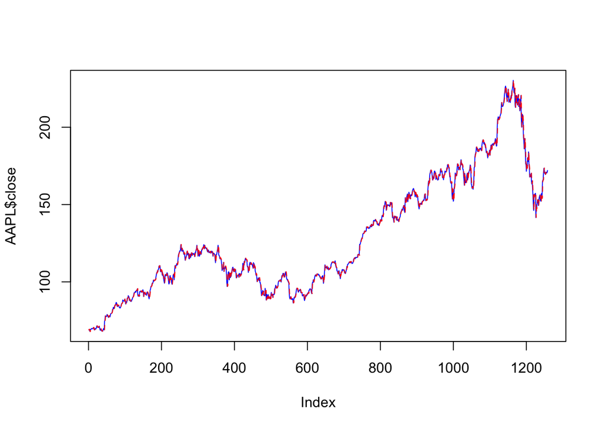

```r
plot(AAPL$close, type = "l", col = 4, lty = 1)
points(model2.arima021_fitted, type = "l", col = 2, lty = 2)
```

```r
library("forecast")
AAPLforecast <- forecast(m021$model, h=150)
```

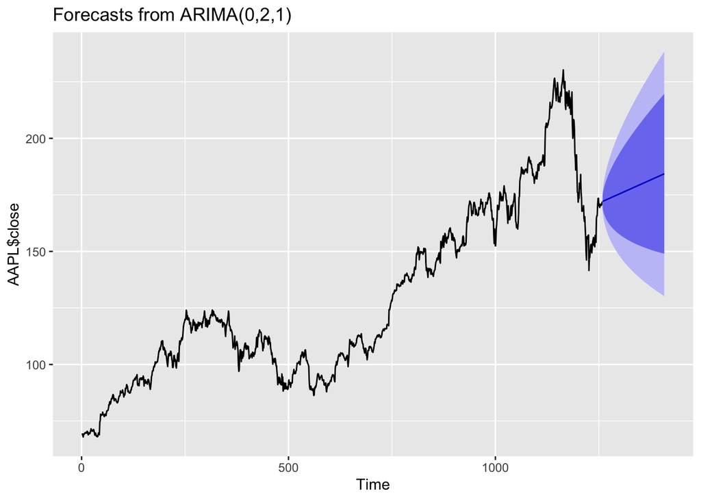

```r
autoplot(AAPLforecast)
```

### Forecast vs Actual

Using 70% training data

```r
AAPLsubset <- AAPL$close[1:round(0.7*length(AAPL$close))]
model3.arima021 <- arima(AAPLsubset, order = c(0, 2, 1))
model3.arima021_fitted <- AAPLsubset - residuals(model3.arima021)
model3.arima021
```

```
##
## Call:
## arima(x = AAPLsubset, order = c(0, 2, 1))
##
## Coefficients:
##           ma1
##       -1.0000
## s.e.   0.0125
##
## sigma^2 estimated as 2.371:  log likelihood = -1630.07,  aic = 3264.14
```

```r
boundary <- round(length(AAPL$close)*.7)
end <- length(AAPL$close)
data <- tibble(date=AAPL$date, price=AAPL$close, prediction = NA, fitted=NA, Low95 = NA,
         Low80 = NA,
         High95 = NA,
         High80 = NA)


AAPLsubsetforecast <- forecast(model3.arima021, h=377)
forecast_df <- fortify(as.data.frame(AAPLsubsetforecast)) %>% as_tibble()
forecast_df <- forecast_df %>%
  rename("Low95" = "Lo 95",
         "Low80" = "Lo 80",
         "High95" = "Hi 95",
         "High80" = "Hi 80",
         "Forecast" = "Point Forecast")

#data[boundary:end,3:7] <- forecast_df

data$fitted <- c(as.vector(model3.arima021_fitted),rep(NA,(end-boundary)))
data$prediction <- c(rep(NA,boundary),forecast_df$Forecast)
data$Low80 <- c(rep(NA,boundary),forecast_df$Low80)
data$High80 <- c(rep(NA,boundary),forecast_df$High80)
data$Low95 <- c(rep(NA,boundary),forecast_df$Low95)
data$High95 <- c(rep(NA,boundary),forecast_df$High95)

tail(data)
```

| date | price | prediction | fitted | Low95 | Low80 | High95 | High80 |
| --- | --- | --- | --- | --- | --- | --- | --- |
| 2019-02-12 | 170.89 | 189.8743 | NA | 120.4437 | 144.4761 | 259.3049 | 235.2726 |
| 2019-02-13 | 170.18 | 189.9709 | NA | 120.4192 | 144.4935 | 259.5225 | 235.4482 |
| 2019-02-14 | 170.80 | 190.0674 | NA | 120.3948 | 144.5110 | 259.7400 | 235.6239 |
| 2019-02-15 | 170.42 | 190.1640 | NA | 120.3705 | 144.5285 | 259.9575 | 235.7995 |
| 2019-02-19 | 170.93 | 190.2605 | NA | 120.3462 | 144.5460 | 260.1749 | 235.9751 |
| 2019-02-20 | 172.03 | 190.3571 | NA | 120.3220 | 144.5636 | 260.3922 | 236.1506 |

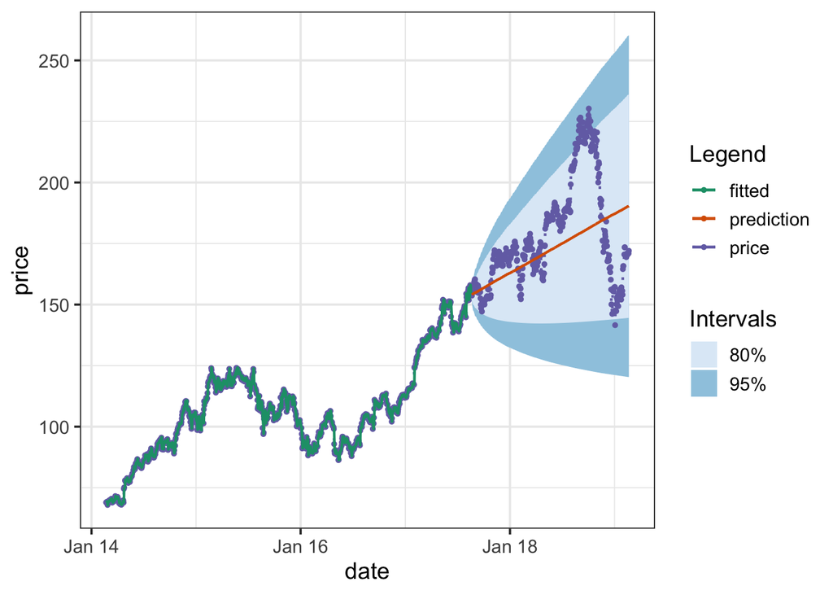

```r
ggplot(data, aes(x = date)) +
  geom_ribbon(aes(ymin = Low95, ymax = High95, fill = "95%")) +
  geom_ribbon(aes(ymin = Low80, ymax = High80, fill = "80%")) +
  geom_point(aes(y = price, colour = "price"), size = 1) +
  geom_line(aes(y = price, group = 1, colour = "price"),
            linetype = "dotted", size = 0.75) +
  geom_line(aes(y = fitted, group = 2, colour = "fitted"), size = 0.75) +
  geom_line(aes(y = prediction, group = 3, colour = "prediction"), size = 0.75) +
  scale_x_date(breaks = scales::pretty_breaks(), date_labels = "%b %y") +
  scale_colour_brewer(name = "Legend", type = "qual", palette = "Dark2") +
  scale_fill_brewer(name = "Intervals") +
  guides(colour = guide_legend(order = 1), fill = guide_legend(order = 2)) +
  theme_bw(base_size = 14)
```

### Model Building

### Model Evaluation

### Results

# Discussion and Conclusion

# Appendix A. Figures

# Appendix B. Tables

# Appendix C. Code

```r
install_load <- function(pkg){
  # Load packages & Install them if needed.
  new.pkg <- pkg[!(pkg %in% installed.packages()[, "Package"])]
  if (length(new.pkg)) install.packages(new.pkg, dependencies = TRUE)
  sapply(pkg, require, character.only = TRUE, quietly = TRUE, warn.conflicts = FALSE)
}
```

# References